# Importing Required Library

```python
import numpy as np
import pandas as pd
```

# Importing CSV File Into Jupyter Notebook

```python
df=pd.read_csv('C:/Users/Lenovo/OneDrive/Desktop/PowerBI/New folder (4)/Data/1234.csv')
```

# Evaluating The CSV File

```python
df.shape
```

```
(149116, 17)
```

```python
df.head(3)
```

|  | transaction_id | transaction_date | transaction_time | transaction_qty | store_id | store_location | product_id | unit_price | product_category | product_type | product_detail | Revenue | Month | Month.1 | Weekday | Weekday.1 | Hour |
| --- | --- | --- | --- | --- | --- | --- | --- | --- | --- | --- | --- | --- | --- | --- | --- | --- | --- |
| 0 | 1 | 01-01-2023 | 7:06:11 | 2 | 5 | Lower Manhattan | 32 | 3.0 | Coffee | Gourmet brewed coffee | Ethiopia Rg | 6.0 | 1 | Jan | 7 | Sun | 7 |
| 1 | 2 | 01-01-2023 | 7:08:56 | 2 | 5 | Lower Manhattan | 57 | 3.1 | Tea | Brewed Chai tea | Spicy Eye Opener Chai Lg | 6.2 | 1 | Jan | 7 | Sun | 7 |
| 2 | 3 | 01-01-2023 | 7:14:04 | 2 | 5 | Lower Manhattan | 59 | 4.5 | Drinking Chocolate | Hot chocolate | Dark chocolate Lg | 9.0 | 1 | Jan | 7 | Sun | 7 |

```python
df.info()
```

```
<class 'pandas.core.frame.DataFrame'>
RangeIndex: 149116 entries, 0 to 149115
Data columns (total 17 columns):
 #   Column            Non-Null Count   Dtype
---  ------            --------------   -----
 0   transaction_id    149116 non-null  int64
 1   transaction_date  149116 non-null  object
 2   transaction_time  149116 non-null  object
 3   transaction_qty   149116 non-null  int64
 4   store_id          149116 non-null  int64
 5   store_location    149116 non-null  object
 6   product_id        149116 non-null  int64
 7   unit_price        149116 non-null  float64
 8   product_category  149116 non-null  object
 9   product_type      149116 non-null  object
 10  product_detail    149116 non-null  object
 11  Revenue           149116 non-null  float64
 12  Month             149116 non-null  int64
 13  Month.1           149116 non-null  object
 14  Weekday           149116 non-null  int64
 15  Weekday.1         149116 non-null  object
 16  Hour              149116 non-null  int64
dtypes: float64(2), int64(7), object(8)
memory usage: 19.3+ MB
```

```python
df.describe()
```

|  | transaction_id | transaction_qty | store_id | product_id | unit_price | Revenue | Month | Weekday | Hour |
| --- | --- | --- | --- | --- | --- | --- | --- | --- | --- |
| count | 149116.000000 | 149116.000000 | 149116.000000 | 149116.000000 | 149116.000000 | 149116.000000 | 149116.000000 | 149116.000000 | 149116.000000 |
| mean | 74737.371872 | 1.438276 | 5.342063 | 47.918607 | 3.382219 | 4.686367 | 3.988881 | 3.982336 | 11.735790 |
| std | 43153.600016 | 0.542509 | 2.074241 | 17.930020 | 2.658723 | 4.227099 | 1.673091 | 1.996650 | 3.764662 |
| min | 1.000000 | 1.000000 | 3.000000 | 1.000000 | 0.800000 | 0.800000 | 1.000000 | 1.000000 | 6.000000 |
| 25% | 37335.750000 | 1.000000 | 3.000000 | 33.000000 | 2.500000 | 3.000000 | 3.000000 | 2.000000 | 9.000000 |
| 50% | 74727.500000 | 1.000000 | 5.000000 | 47.000000 | 3.000000 | 3.750000 | 4.000000 | 4.000000 | 11.000000 |
| 75% | 112094.250000 | 2.000000 | 8.000000 | 60.000000 | 3.750000 | 6.000000 | 5.000000 | 6.000000 | 15.000000 |
| max | 149456.000000 | 8.000000 | 8.000000 | 87.000000 | 45.000000 | 360.000000 | 6.000000 | 7.000000 | 20.000000 |

```python
pd.isnull(df).sum()
```

```
transaction_id      0
transaction_date    0
transaction_time    0
transaction_qty     0
store_id            0
store_location      0
product_id          0
unit_price          0
product_category    0
product_type        0
product_detail      0
Revenue             0
Month               0
Month.1             0
Weekday             0
Weekday.1           0
Hour                0
dtype: int64
```

# Total Revenue Generated

```python
df['Revenue'].sum()
```

```
698812.3300000002
```

# Mean Revenue Earned in Each Category

```python
df.groupby('product_category')['Revenue'].mean()
```

```
product_category
Bakery                 3.610969
Branded               18.215529
Coffee                 4.621207
Coffee beans          22.866657
Drinking Chocolate     6.314615
Flavours               1.238409
Loose Tea              9.267438
Packaged Chocolate     9.050595
Tea                    4.321458
Name: Revenue, dtype: float64
```

# Total Revenue Generated by All Store is $698812

# Total FootFall

```python
df['transaction_id'].count()
```

```
149116
```

# Total Footfall of Coffee Shop is 149116

# Average Revenue Generated Per Customer

```python
df['Revenue'].mean()
```

```
4.686367190643527
```

# On average the coffee shop generate $ 4.7 from each customer

# Max Revenue in Single order

```python
df['Revenue'].max()
```

```
360.0
```

# Max Revenue Generate by Coffee Shop in Single Order is $ 360

```python
df['Revenue'].min()
```

```
0.8
```

# Min Revenue Generated by Coffee Shop in Single Order is $ 0.8

# Footfall in Each Store

```python
freq_table=pd.crosstab(df['store_location'],'FootFall')
freq_table
```

| col_0 store_location | FootFall |
| --- | --- |
| Astoria | 50599 |
| Hell's Kitchen | 50735 |
| Lower Manhattan | 47782 |

# From Above Table We Can Conclude That FootFall of Hell's Kitchen Coffee Shop is Max i.e. 50735 and Lower Manhattan Coffee Shop is Min i.e. 47782

# Quantity Sold by Product Category

```python
freq_table=pd.crosstab(df['product_category'],'Quantity Sold')
freq_table
```

| col_0 product_category | Quantity Sold |
| --- | --- |
| Bakery | 22796 |
| Branded | 747 |
| Coffee | 58416 |
| Coffee beans | 1753 |
| Drinking Chocolate | 11468 |
| Flavours | 6790 |
| Loose Tea | 1210 |
| Packaged Chocolate | 487 |
| Tea | 45449 |

# From The Above Table We Can Conclude That People Mostly Prefer Coffee, Tea and Bakery Products And Least Prefered Is Packaged Chocolate, Branded And Loose Tea.

# Most Sold Product In Coffee Shop

```python
df['product_detail'].mode()
```

```
0    Chocolate Croissant
Name: product_detail, dtype: object
```

# People Prefers Chocolate Croissant Most

# Quantity Sold Monthwise

```python
freq_table=pd.crosstab(df['Month.1'],'Quantity Sold')
freq_table
```

| col_0 Month.1 | Quantity Sold |
| --- | --- |
| Apr | 25335 |
| Feb | 16359 |
| Jan | 17314 |
| Jun | 35352 |
| Mar | 21229 |
| May | 33527 |

# From Above Table We Can Conclude That In June Month The FootFall Is Max And In Feb Month The FootFall Is Min.

# Quantity Sold On Weekdays

```python
freq_table=pd.crosstab(df['Weekday.1'],'Quantity Sold')
freq_table
```

| col_0 Weekday.1 | Quantity Sold |
| --- | --- |
| Fri | 21701 |
| Mon | 21643 |
| Sat | 20510 |
| Sun | 21096 |
| Thu | 21654 |
| Tue | 21202 |
| Wed | 21310 |

# From Above Table We Can Say That Friday,Thrusday and Monday Is Busiest Day In Coffee Shop And Saturday,Sunday And Tueday Is Least Active Days.

# Peak Hour

```python
freq_table=pd.crosstab(df['Hour'],'Quantity Sold')
freq_table
```

| col_0 Hour | Quantity Sold |
| --- | --- |
| 6 | 4594 |
| 7 | 13428 |
| 8 | 17654 |
| 9 | 17764 |
| 10 | 18545 |
| 11 | 9766 |
| 12 | 8708 |
| 13 | 8714 |
| 14 | 8933 |
| 15 | 8979 |
| 16 | 9093 |
| 17 | 8745 |
| 18 | 7498 |
| 19 | 6092 |
| 20 | 603 |

# From Above Table We Can Say That People Go To Coffee Shop Most On 10AM, 9AM and 8AM And Least On 20PM, 6AM And 19PM.

# Quantity Sold By Product Type

```python
freq_table=pd.crosstab(df['product_type'],'Quantity Sold')
freq_table
```

| col_0 product_type | Quantity Sold |
| --- | --- |
| Barista Espresso | 16403 |
| Biscotti | 5711 |
| Black tea | 303 |
| Brewed Black tea | 11350 |
| Brewed Chai tea | 17183 |
| Brewed Green tea | 5671 |
| Brewed herbal tea | 11245 |
| Chai tea | 443 |
| Clothing | 221 |
| Drinking Chocolate | 266 |
| Drip coffee | 8477 |
| Espresso Beans | 319 |
| Gourmet Beans | 366 |
| Gourmet brewed coffee | 16912 |
| Green beans | 134 |
| Green tea | 159 |
| Herbal tea | 305 |
| Hot chocolate | 11468 |
| House blend Beans | 183 |
| Housewares | 526 |
| Organic Beans | 415 |
| Organic Chocolate | 221 |
| Organic brewed coffee | 8489 |
| Pastry | 6912 |
| Premium Beans | 336 |
| Premium brewed coffee | 8135 |
| Regular syrup | 4979 |
| Scone | 10173 |
| Sugar free syrup | 1811 |

# Most Prefered Product Types Are Brewed Chai Tea, Gourmet Brewed Coffee And Barista Espresso And Least Predered Product Type Is Green Beans, Green Tea , And House Blend Beans

```python
import matplotlib.pyplot as plt
import seaborn as sns
```

# Store By FootFall

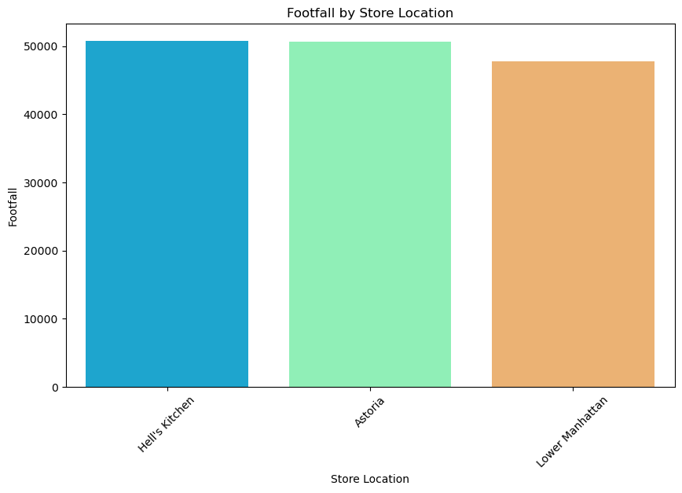

```python
footfall_by_location = df.groupby('store_location')['transaction_id'].count().sort_values(ascending=False)
plt.figure(figsize=(10, 6))
sns.barplot(x=footfall_by_location.index, y=footfall_by_location.values, palette='rainbow')
plt.title('Footfall by Store Location')
plt.xlabel('Store Location')
plt.ylabel('Footfall')
plt.xticks(rotation=45)
plt.show()
```

# Revenue By Store Location

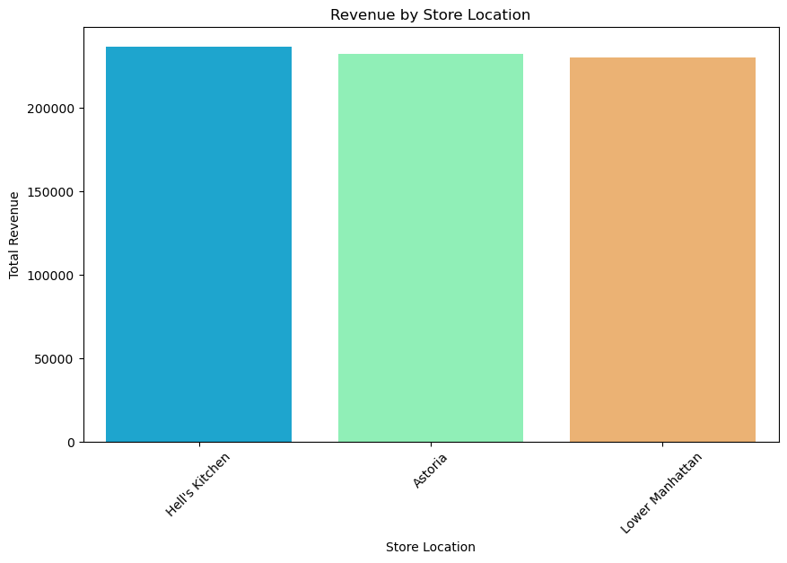

```python
revenue_by_location = df.groupby('store_location')['Revenue'].sum().sort_values(ascending=False)
plt.figure(figsize=(10, 6))
sns.barplot(x=revenue_by_location.index, y=revenue_by_location.values, palette='rainbow')
plt.title('Revenue by Store Location')
plt.xlabel('Store Location')
plt.ylabel('Total Revenue')
plt.xticks(rotation=45)
plt.show()
```

# Top 3 Revenue Generating Products

[figure not shown]

```python
revenue_per_product = df.groupby('product_type')['Revenue'].sum().sort_values(ascending=False).head(3)
plt.figure(figsize=(12, 6))
sns.barplot(x=revenue_per_product.index, y=revenue_per_product.values, palette='coolwarm')
plt.title('Top 5 Revenue-Generating Products')
plt.xlabel('Product Type')
plt.ylabel('Total Revenue')
plt.xticks(rotation=45)
plt.show()
```

# Bottom 3 Revenue Generating Product

[figure not shown]

```python
revenue_per_product = df.groupby('product_type')['Revenue'].sum().sort_values(ascending=False).tail(3)
plt.figure(figsize=(12, 6))
sns.barplot(x=revenue_per_product.index, y=revenue_per_product.values, palette='coolwarm')
plt.title('Top 5 Revenue-Generating Products')
plt.xlabel('Product Type')
plt.ylabel('Total Revenue')
plt.xticks(rotation=45)
plt.show()
```

# Products By Total Revenue

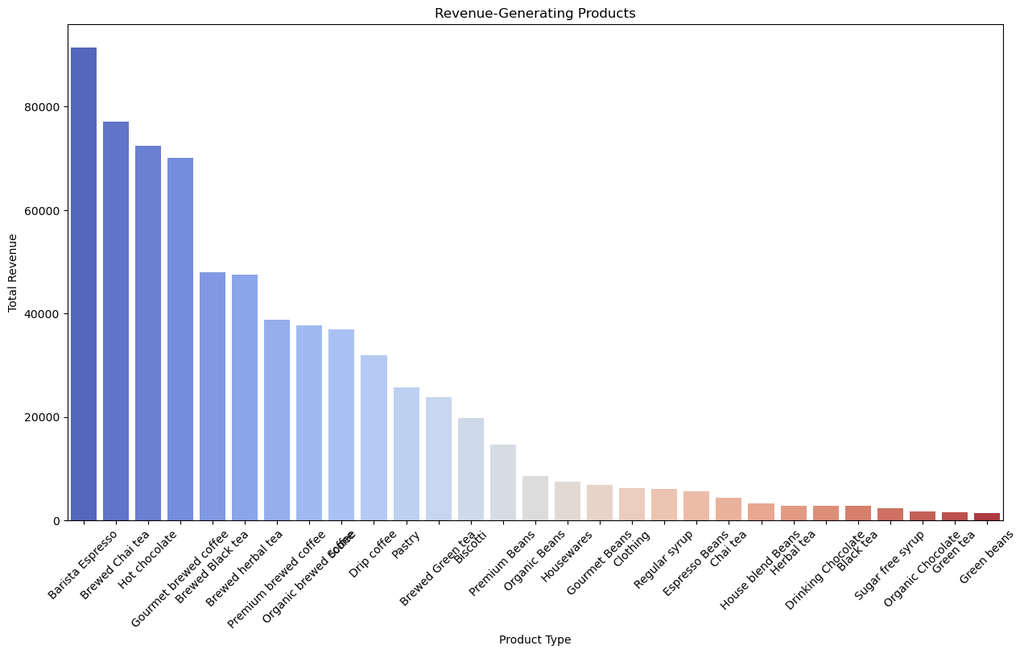

```python
revenue_per_product = df.groupby('product_type')['Revenue'].sum().sort_values(ascending=False)
plt.figure(figsize=(15, 8))
sns.barplot(x=revenue_per_product.index, y=revenue_per_product.values, palette='coolwarm')
plt.title('Revenue-Generating Products')
plt.xlabel('Product Type')
plt.ylabel('Total Revenue')
plt.xticks(rotation=45)
plt.show()
```